# Laboratorio 3.1: Clustering

Felipe Bravo, Hernán Sarmiento, Gabriel Iturra, María José Zambrano

Mayo 2023

## Nombres

- Diego Ignacio Faúndez Ortega
- Javier Ignacio Kauer Lara

# Instrucciones

1. Trabajen en equipos de dos personas. Salvo excepciones, no se corregirá entregas con menos de dos integrantes.
2. Modifique este archivo `.ipynb` agregando sus respuestas donde corresponda.
3. El formato de entrega para esta actividad es un archivo **html**. Genere un archivo HTML usando jupyter (ver tutorial 2) y súbalo a U-Cursos. Basta con que **uno de los integrantes haga la entrega**. Si ambos hacen una entrega en U-Cursos, se revisará cualquiera de éstas.

## Preguntas teóricas

### Pregunta 1

Verdadero o Falso (si la afirmación es falsa justifique):

1. El algoritmo DBSCAN se caracteriza por generar grupos a partir de centroides iniciales.

**Respuesta:** Falso. Porque este algoritmo genera grupos a partir de datos con mucho ruido, outliers y que tengan una forma poco clara. Más aún este algoritmo es basado en densidades. Entonces no necesita un centroide inicial.

1. El único método para validar clusters es mediante la estructura de los grupos formados, método conocido como validacion interna.

**Respuesta:** Falso. Existe también la validacion externa, y validación relativo.

1. Los métodos de clustering pueden servir para encontrar outliers.

**Respuesta:** Verdadero.

## Preguntas practicas

Un amante de los pingüinos ha ido a la Antártica a recorrer las islas Biscoe, Dream y Torgersen en busca de su ave favorita. Cada vez que encontró un pingüino, anotó su sexo, su peso, la longitud de sus aletas y la longitud y profundidad de su pico.

Luego de su travesía, esta persona nos ha encargado averiguar cuántos tipos de pingüinos encontró. El desafío de este laboratorio será descubrir mediante Clustering las especies de los pingüinos de los datos recolectados.

Ejecute el siguiente código para cargar el dataset:

```python
import pandas as pd
import numpy as np

df = pd.read_csv("https://raw.githubusercontent.com/mzambrano1/Datasets-CC5205-otono-2023/master/lab3.1/penguins.csv", sep=",")

df.head()
```

|  | island | bill_length_mm | bill_depth_mm | flipper_length_mm | body_mass_g | sex |
| --- | --- | --- | --- | --- | --- | --- |
| 0 | Torgersen | 39.1 | 18.7 | 181.0 | 3750.0 | MALE |
| 1 | Torgersen | 39.5 | 17.4 | 186.0 | 3800.0 | FEMALE |
| 2 | Torgersen | 40.3 | 18.0 | 195.0 | 3250.0 | FEMALE |
| 3 | Torgersen | 36.7 | 19.3 | 193.0 | 3450.0 | FEMALE |
| 4 | Torgersen | 39.3 | 20.6 | 190.0 | 3650.0 | MALE |

Para comenzar convertiremos la información categórica en información numérica. De esta forma tenemos un dataset completamente numérico.

```python
df_island = pd.get_dummies(df['island'], prefix='island', prefix_sep='_')
df_sex = pd.get_dummies(df['sex'], prefix='sex', prefix_sep='_', drop_first=True)
X = pd.concat([df, df_island, df_sex], axis=1).drop('sex', axis=1).drop('island', axis=1)
X.head()
```

|  | bill_length_mm | bill_depth_mm | flipper_length_mm | body_mass_g | island_Biscoe | island_Dream | island_Torgersen | sex_MALE |
| --- | --- | --- | --- | --- | --- | --- | --- | --- |
| 0 | 39.1 | 18.7 | 181.0 | 3750.0 | 0 | 0 | 1 | 1 |
| 1 | 39.5 | 17.4 | 186.0 | 3800.0 | 0 | 0 | 1 | 0 |
| 2 | 40.3 | 18.0 | 195.0 | 3250.0 | 0 | 0 | 1 | 0 |
| 3 | 36.7 | 19.3 | 193.0 | 3450.0 | 0 | 0 | 1 | 0 |
| 4 | 39.3 | 20.6 | 190.0 | 3650.0 | 0 | 0 | 1 | 1 |

### Pregunta 2

Primero intentaremos encontrar la cantidad de especies de pingüinos en los datos usando K-Means. Para esto utilice el método del codo para estimar la cantidad de clusters que se ajusten a los datos:

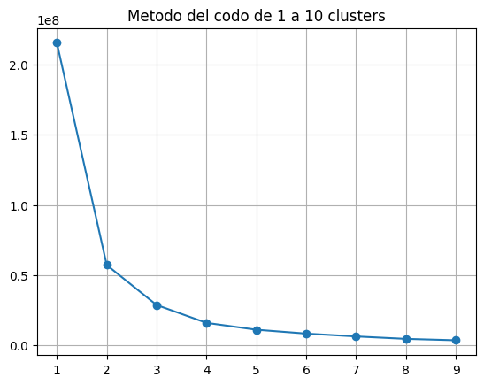

```python
import matplotlib.pyplot as plt
from sklearn.cluster import KMeans

sse = []

clusters = list(range(1, 10))
for k in clusters:
    kmeans = KMeans(n_clusters=k,n_init='auto').fit(X)
    sse.append(kmeans.inertia_)

plt.plot(clusters, sse, marker="o")
plt.title("Metodo del codo de 1 a 10 clusters")
plt.grid(True)
plt.show()
```

**1.** ¿Cuántos clusters propone usar para este dataset? Justifique su elección y recuerde que hay varias respuestas posibles.

> Respuesta: Se propone usar 4 o 5 clusters para este dataset. La razón de esto porque la diferencia entre los distintos clusters es cada vez menos significativa, y problablemente se estarían dividiendos clusters que se tenían anteriormente. Para trabajara se usará 5 clusters.

**2.** Entrene un modelo de K-Means usando el número de clusters que eligió en la pregunta anterior e imprima las asignaciones de clusters para cada dato.

```python
kmeans = KMeans(n_clusters=5, random_state=20,n_init='auto').fit(X)
```

```python
kmeans.labels_
```

```
array([3, 3, 1, 1, 3, 3, 4, 1, 3, 0, 3, 1, 0, 1, 0, 1, 3, 3, 3, 3, 3, 1,
       1, 1, 3, 1, 3, 1, 3, 1, 0, 3, 1, 1, 0, 1, 3, 1, 0, 1, 0, 1, 1, 0,
       1, 0, 1, 3, 1, 3, 1, 3, 1, 3, 1, 0, 3, 3, 1, 3, 1, 3, 1, 0, 3, 3,
       1, 0, 3, 0, 3, 3, 1, 3, 1, 4, 3, 0, 1, 1, 3, 1, 3, 3, 1, 0, 1, 0,
       1, 0, 3, 0, 1, 3, 3, 4, 1, 0, 1, 1, 3, 3, 1, 4, 3, 0, 1, 0, 3, 3,
       1, 3, 1, 1, 1, 1, 1, 3, 1, 3, 1, 0, 1, 3, 1, 1, 1, 0, 1, 3, 1, 3,
       1, 0, 1, 1, 1, 3, 1, 3, 0, 1, 1, 3, 3, 3, 1, 3, 3, 1, 3, 3, 1, 3,
       0, 3, 3, 3, 3, 3, 3, 3, 1, 3, 1, 0, 3, 1, 1, 3, 1, 0, 1, 3, 3, 0,
       1, 0, 1, 3, 3, 3, 3, 4, 1, 0, 3, 3, 1, 1, 3, 0, 1, 0, 1, 3, 1, 3,
       3, 3, 1, 1, 1, 3, 3, 1, 3, 3, 3, 3, 1, 3, 3, 3, 0, 2, 0, 2, 2, 0,
       4, 4, 0, 4, 0, 2, 0, 2, 0, 2, 0, 2, 4, 2, 2, 4, 0, 4, 4, 4, 2, 0,
       2, 4, 4, 4, 2, 4, 2, 4, 4, 0, 2, 3, 2, 0, 4, 2, 4, 0, 2, 4, 2, 4,
       2, 0, 4, 4, 4, 0, 4, 0, 2, 0, 2, 0, 2, 4, 2, 2, 4, 2, 4, 4, 4, 4,
       4, 2, 0, 2, 4, 2, 0, 2, 4, 2, 4, 2, 0, 2, 4, 2, 4, 2, 4, 2, 4, 4,
       4, 4, 0, 4, 4, 2, 4, 2, 2, 4, 2, 0, 2, 4, 2, 0, 2, 0, 2, 2, 4, 4,
       2, 4, 2], dtype=int32)
```

### Pregunta 4

Utilizando PCA reduciremos la dimensionalidad de los datos a 2 y guardaremos los datos nuevos en una variable llamada new_x.

```python
from sklearn.decomposition import PCA
new_X = PCA(n_components=2, random_state=0).fit_transform(X)
```

Ahora grafique los datos transformados pintando los datos para tener una representación visual de los clusters.

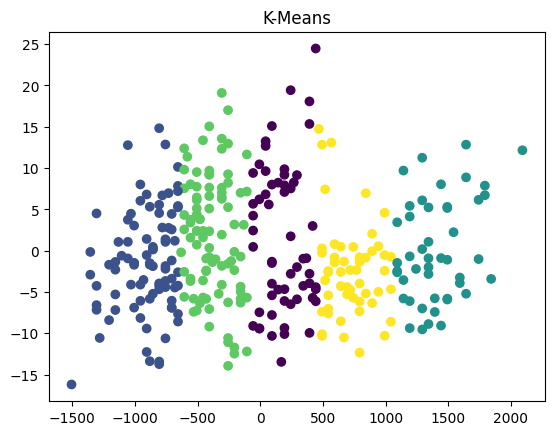

```python
plt.scatter(new_X[:, 0], new_X[:, 1], c=kmeans.labels_)
plt.title("K-Means")
plt.show()
```

### Pregunta 5

**1.** Usando el dataframe de datos numéricos ejecute cada uno de los 4 métodos de clustering jerárquico: complete, single, average y ward, y visualice los dendrogramas formados. Adjunte el código necesario. No necesita generar los 4 dendrogramas en el mismo gráfico, pueden ser distintos.

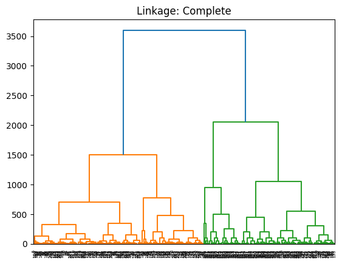

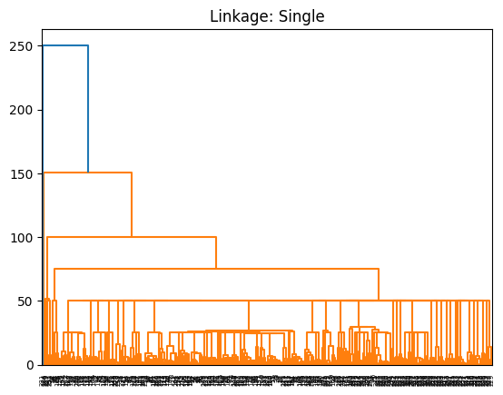

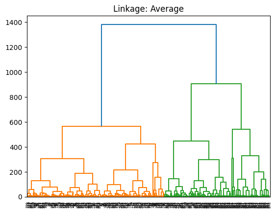

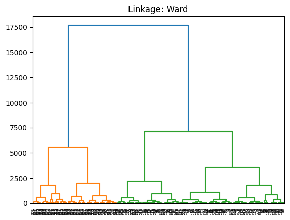

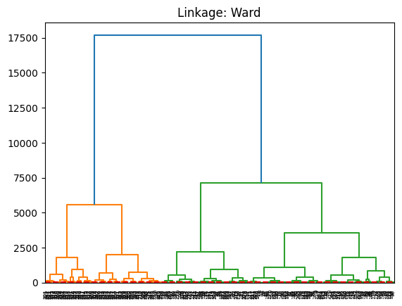

```python
from scipy.cluster.hierarchy import dendrogram, linkage


complete = linkage(X, method="complete")
single = linkage(X, method="single")
average = linkage(X, method="average")
ward = linkage(X, method="ward")

dendrogram(complete)
plt.title("Linkage: Complete")
plt.show()

dendrogram(single)
plt.title("Linkage: Single")
plt.show()

dendrogram(average)
plt.title("Linkage: Average")
plt.show()

dendrogram(ward)
plt.title("Linkage: Ward")
plt.show()

dendrogram(ward)
plt.title("Linkage: Ward")
plt.axhline(y=50, color='r', linestyle='--')
plt.show()
```

**2.** Fijándose en el método `complete`, ¿"visualmente" cuántos clusters propone usar? ¿A qué altura recomendaría cortar el árbol?

**3.** Implemente el código para asignar clusters a los datos siguiendo lo que usted propuso en la pregunta anterior y liste la asignación de clusters para cada registro del dataset usando el método `complete`. Señale cuántos clusters se generan cortando la altura que propuso en la pregunta anterior.

```python
from sklearn.cluster import AgglomerativeClustering

complete_all = AgglomerativeClustering(n_clusters=None, linkage="complete", distance_threshold=500).fit(X)
print(complete_all.n_clusters_)
```

```
10
```

**4.** ¿Cuántos datos quedan asignados a cada cluster? Agregue el código necesario para obtener esta información con el método `complete`.

```python
complete_all.labels_

amount = np.bincount(complete_all.labels_)

print("Ordenado del cluster 1 al cluster 10:", amount)
```

```
Ordenado del cluster 1 al cluster 10: [60 38 50 70 22  6  8 35 30 14]
```

**5.** Usando el dataset con dimensiones reducidas generado en la parte K-means (`new_X`), grafique los datos y píntelos con su asignacion de clusters según el métodos `complete` para tener una representación visual de los clusters.

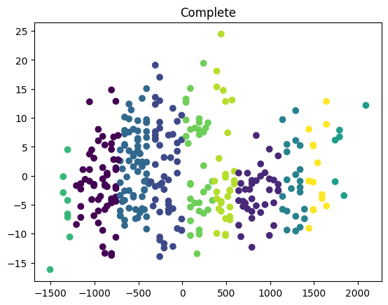

```python
plt.scatter(new_X[:, 0], new_X[:, 1], c=complete_all.labels_)
plt.title("Complete")
plt.show()
```

### Pregunta 6

**1.** Ahora con los mismos datos ejecute dbscan y grafique los datos pintando los clusters encontrados. ¿Cuántos clusters se encontraron?

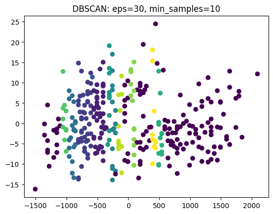

```python
from  sklearn.cluster import DBSCAN

eps = 30
min_samples = 10

dbscan = DBSCAN(eps=eps, min_samples=min_samples).fit(X)
plt.scatter(new_X[:,0], new_X[:,1], c=dbscan.labels_)
plt.title(f"DBSCAN: eps={eps}, min_samples={min_samples}")
plt.show()
```

**1.** Ahora comparando los 3 métodos de clustering que utilizamos, ¿cuál crees que es el que mejor separa los datos? ¿Por qué?

> Respuesta: Dentro de los 3 métodos utilizados, el que se considera mejor para separar los datos corresponde a el método de K-Means. Esto debido a que agrupa un nivel razonable de clusters, no teniendo clusters con pocos puntos, y clusters que abarcan una cantidad considerable de puntos, sin englobar una parte demasiado significativa del conjunto de datos.

### Pregunta 7

Un experto en pingüinos ha analizado los datos y ha determinado que los pingüinos encontrados corresponden a 3 tipos de especies: Adelie, Gentoo y Chinstrap.

[figure not shown]

```python
df_s = pd.read_csv("https://raw.githubusercontent.com/mzambrano1/Datasets-CC5205-otono-2023/master/lab3.1/penguins_species.csv", sep=",")
df_s =  pd.DataFrame(df_s['species'])
df_s.value_counts()
```

```
species
Adelie       146
Gentoo       119
Chinstrap     68
dtype: int64
```

Compare la clasificación del experto con los resultados con alguno de sus modelos de clustering. ¿Qué puede decir de los clusters generados? ¿Cómo se comportan en comparación al anotado del experto?

Hint: puede ocupar métricas de comparación, visualizaciones o bien usar los métodos [groupby](https://pandas.pydata.org/pandas-docs/stable/reference/api/pandas.DataFrame.groupby.html) y [value_counts](https://pandas.pydata.org/pandas-docs/stable/reference/api/pandas.DataFrame.value_counts.html) de pandas para comparar los datos de las tablas.

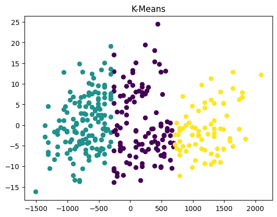

```python
kmeans = KMeans(n_clusters=3, random_state=20,n_init='auto').fit(X)

plt.scatter(new_X[:, 0], new_X[:, 1], c=kmeans.labels_)
plt.title("K-Means")
plt.show()
```

```python
amount = np.bincount(kmeans.labels_)
print(amount)
```

```
[111 150  72]
```

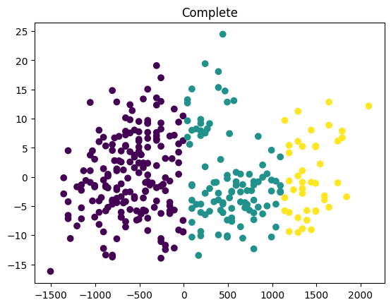

```python
from sklearn.cluster import AgglomerativeClustering

complete_all = AgglomerativeClustering(n_clusters=3, linkage="complete", distance_threshold=None).fit(X)

plt.scatter(new_X[:, 0], new_X[:, 1], c=complete_all.labels_)
plt.title("Complete")
plt.show()
```

```python
amount = np.bincount(complete_all.labels_)
print(amount)
```

```
[188 103  42]
```

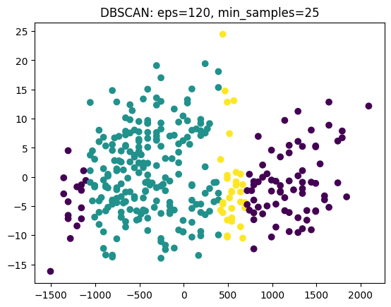

```python
eps = 120
min_samples = 25

dbscan = DBSCAN(eps=eps, min_samples=min_samples).fit(X)
plt.scatter(new_X[:,0], new_X[:,1], c=dbscan.labels_)
plt.title(f"DBSCAN: eps={eps}, min_samples={min_samples}")
plt.show()
```

```python
a1 = 0
a2 = 0
a3 = 0

for element in dbscan.labels_:
  if(element == -1):
    a1+=1
  if(element == 0):
    a2+=1
  if(element == 1):
    a3+=1

print(a1, a2, a3)
```

```
88 213 32
```